# Coda4MicrobiomePractical2_html

Pierre Wensel

16 February, 2024

Project: Coda4Microbiome Practical Assignment Date: February 16, 2024 Student Name: Pierre Wensel Instructor Name: Dr. Mallu Calle Course: UVic MS Omics Data Analysis - Applications

Introduction: Text from the following website:https://malucalle.github.io/statistical-pills/coda4microbiome.html

“Understanding the role of the microbiome in human health and how it can be modulated is becoming increasingly relevant for preventive medicine and for the medical management of chronic diseases (Calle 2019).#High-throughput sequencing technologies has boosted microbiome research but the compositional nature of microbiome data is a major challenge for their analysis. Microbiome count data is compositional since their total are constrained by the sequencing depth. Relative abundances (proportions) are obviously constraint by a sum equal to one. This total constraint induces strong dependencies among the observed abundances of the different taxa. In fact, nor the absolute abundance (read counts) nor the relative abundance (proportion) of one taxon alone are informative of the real abundance of the taxon in the environment. Instead, they provide information on the relative measure of abundance when compared to the abundance of other taxa in the same sample. We use a new package, coda4microbiome, that aims to bridge the gap between microbiome research and compositional data analysis (CoDA).

PART#1

We will use the coda_glmnet() function from the code4microbiome R package for Cross-sectional analysis of the following cross-sectional study with categorical binary output response variable relating to disease status (T2D vs. healthy) Data set Qin et al. (2012) Type2 Diabetes microbiome study: https://www.nature.com/articles/nature11450

The algorithm checks if the outcome is binary or continuous. According to this, for a pair of variables A and B, different measures of association between the outcome and the pairwise log-ratio log(A/B) are available: For binary outcomes:“AUC”: Discrimination accuracy (AUC) of the log-ratio log(A/B) for the outcome Y (default) “glm”: Discrimination accuracy (AUC) of the predictions of the logistic regression model glm(y ~log(A/B)+covar)for the outcome Y

```r
set.seed(123)
load("C:/Users/click/OneDrive/Desktop/MY_R_DIRECTORY/qin.RData")

#Checking phyloseq object variables in the RStudio environment:
#Examining the abundance matrix x:
class(x)
```

```
## [1] "matrix" "array"
```

```r
#[1] "matrix" "array"
dim(x)
```

```
## [1] 363  49
```

```r
#[1] 363  49
head(x)
```

```
##              taxa1      taxa2        taxa3       taxa4       taxa5      taxa6
## CON.001 0.09808694 0.08811007 0.0573621187 0.053633060 0.114775135 0.21760830
## CON.002 0.00000000 0.41460614 0.0000000000 0.017649121 0.089682413 0.30778471
## CON.003 0.12631946 0.06843528 0.0007842351 0.006279228 0.091418624 0.07181749
## CON.004 0.00000000 0.21866649 0.0000000000 0.123774659 0.019998552 0.43769871
## CON.005 0.01802309 0.11296721 0.0228518873 0.040373824 0.103952440 0.12925366
## CON.006 0.00000000 0.40103074 0.0052095284 0.006543562 0.001750768 0.26194141
##               taxa7      taxa8       taxa9       taxa10      taxa11
## CON.001 0.032852524 0.05612758 0.027116246 4.530369e-02 0.017083593
## CON.002 0.003026153 0.01423775 0.006763016 4.082465e-05 0.000000000
## CON.003 0.007816220 0.01582413 0.005442226 3.870106e-01 0.005840347
## CON.004 0.000000000 0.05575866 0.000000000 5.280776e-05 0.000000000
## CON.005 0.007952616 0.01372687 0.018780463 2.456658e-01 0.006587938
## CON.006 0.000000000 0.03489209 0.000000000 2.821373e-05 0.000000000
##               taxa12       taxa13      taxa14      taxa15      taxa16
## CON.001 0.0159769660 0.0154172071 0.015006250 0.009874071 0.009429220
## CON.002 0.0000000000 0.0003967835 0.034119154 0.000544798 0.001723685
## CON.003 0.0001517419 0.0007997725 0.008486648 0.004803982 0.001022744
## CON.004 0.0000000000 0.0001137630 0.013115135 0.000000000 0.008003746
## CON.005 0.0003926301 0.0176258273 0.035739347 0.011764475 0.011565523
## CON.006 0.0000000000 0.0004953077 0.066534949 0.006444359 0.007182568
##              taxa17       taxa18       taxa19      taxa20       taxa21
## CON.001 0.009643589 0.0037236136 0.0054674565 0.003437455 0.0030107183
## CON.002 0.003329019 0.0023048835 0.0006902986 0.003802022 0.0006113643
## CON.003 0.001053415 0.0001918970 0.0016846980 0.000000000 0.0001166314
## CON.004 0.002604177 0.0007273389 0.0000000000 0.000000000 0.0010896505
## CON.005 0.016360949 0.0028139743 0.0046453507 0.005857692 0.0005342008
## CON.006 0.008257420 0.0049292114 0.0000000000 0.000000000 0.0013534500
##               taxa22       taxa23       taxa24      taxa25       taxa26
## CON.001 2.728783e-03 0.0025135253 2.431845e-03 0.002323938 0.0016656078
## CON.002 6.152859e-04 0.0002319765 3.549533e-05 0.002244149 0.0010140804
## CON.003 4.180932e-02 0.0002395181 8.423893e-02 0.000301365 0.0002678688
## CON.004 2.250315e-03 0.0014662453 1.005862e-05 0.006022097 0.0052158983
## CON.005 8.182036e-05 0.0038844214 5.203882e-03 0.005925086 0.0036007416
## CON.006 8.239622e-04 0.0005596228 9.414790e-03 0.001817814 0.0248050244
##               taxa27       taxa28      taxa29       taxa30       taxa31
## CON.001 3.292354e-02 0.0032263094 0.012795219 0.0007272309 0.0038061827
## CON.002 7.340393e-06 0.0157420268 0.031537850 0.0003038722 0.0050579333
## CON.003 3.864877e-03 0.0003157926 0.026554121 0.0011079981 0.0008674711
## CON.004 7.199961e-04 0.0003196630 0.001936285 0.0002582048 0.0012419380
```

[output cut: 8 more lines]

```
## CON.006 0.013697007 0.000000000 0.00000000 0.0016773516 0.000000000 0.053244260
##               taxa38      taxa39       taxa40       taxa41       taxa42
## CON.001 0.0000000000 0.000000000 2.068119e-04 0.0000000000 0.0088389009
## CON.002 0.0000000000 0.000000000 5.832093e-06 0.0000000000 0.0032165001
## CON.003 0.0013577063 0.001754314 2.007755e-04 0.0000000000 0.0000000000
## CON.004 0.0004657142 0.000000000 6.025114e-05 0.0220639889 0.0004810033
## CON.005 0.0000000000 0.000000000 1.173476e-04 0.0059711635 0.0011167402
## CON.006 0.0000000000 0.000000000 2.320807e-04 0.0001228662 0.0057844210
##               taxa43      taxa44       taxa45 taxa46 taxa47       taxa48 taxa49
## CON.001 0.0000000000 0.000000000 0.0000000000      0      0 9.201516e-05      0
## CON.002 0.0000000000 0.000000000 0.0000000000      0      0 0.000000e+00      0
## CON.003 0.0000000000 0.000000000 0.0000000000      0      0 0.000000e+00      0
## CON.004 0.0000000000 0.000000000 0.0000000000      0      0 0.000000e+00      0
## CON.005 0.0006289402 0.000000000 0.0000000000      0      0 1.195654e-03      0
## CON.006 0.0000000000 0.003260658 0.0001582598      0      0 6.165559e-04      0
```

```r
#Evidently, rows are samples and columns are variables (taxa)

#QC Checking if the count read matrix has NA values:
is.na(x)
```

[output not shown]

[output cut: 1765 more lines]

[output not shown]

```r
#Evidently, there are no NA values from ubiquitous FALSE output
#QC Checking if the count read matrix has zero values, which lead to errors from log(0)=infinity
any(x==0)
```

```
## [1] TRUE
```

```r
#Alternatively:
0 %in% x
```

```
## [1] TRUE
```

```r
#Evidently, based on boolean TRUE output, the count read matrix has zero values.
#Therefore, the coda4microbiome::impute_zeros() function is used to rectify. Based on
#help documentation, impute_zeros() function performs simple imputation:
#When the abundance table contains zeros, a positive value is added
#to all the values in the table. It adds 1 when the minimum of table is larger than 1
#(i.e. tables of counts) or it adds half of the minimum value of the table, otherwise.
x<-impute_zeros(x)
any(x==0)
```

```
## [1] FALSE
```

```r
#Examining the dataframe taxanames:
class(taxanames)
```

```
## [1] "data.frame"
```

```r
#[1] "data.frame"
dim(taxanames)
```

```
## [1] 49  2
```

```r
#[1] 49  2
colnames(taxanames)
```

```
## [1] "taxanames" "namestaxa"
```

```r
head(taxanames)
```

```
##                                                                                                                               taxanames
## 1                  k__Bacteria|p__Firmicutes|c__Negativicutes|o__Veillonellales|f__Veillonellaceae|g__Dialister|s__Dialister_sp_CAG_357
## 2                 k__Bacteria|p__Bacteroidetes|c__Bacteroidia|o__Bacteroidales|f__Bacteroidaceae|g__Bacteroides|s__Bacteroides_vulgatus
## 3 k__Bacteria|p__Verrucomicrobia|c__Verrucomicrobiae|o__Verrucomicrobiales|f__Akkermansiaceae|g__Akkermansia|s__Akkermansia_muciniphila
## 4       k__Bacteria|p__Firmicutes|c__Clostridia|o__Clostridiales|f__Ruminococcaceae|g__Faecalibacterium|s__Faecalibacterium_prausnitzii
## 5                    k__Bacteria|p__Bacteroidetes|c__Bacteroidia|o__Bacteroidales|f__Rikenellaceae|g__Alistipes|s__Alistipes_putredinis
## 6                k__Bacteria|p__Bacteroidetes|c__Bacteroidia|o__Bacteroidales|f__Bacteroidaceae|g__Bacteroides|s__Bacteroides_uniformis
##   namestaxa
## 1     taxa1
## 2     taxa2
## 3     taxa3
## 4     taxa4
## 5     taxa5
## 6     taxa6
```

```r
#Assigning rownames:
#rownames(taxanames)<-taxanames$namestaxa
#Filtering taxanames variable for genus-level name only:
#taxanames <- taxanames %>% mutate(genus = str_remove_all(taxanames, "^g\\$"))
#taxanames<-transform(taxanames,genus = gsub("^g__", "\\1", taxanames))
#taxanames$genus<-grep("^g__.+s__$", taxanames$taxanames, value=TRUE, ignore.case = TRUE)
taxanames$genus<-gsub(".*g__(.+)s__.*", "\\1", taxanames$taxanames)
taxanames$genus<-gsub("\\|", "", as.character(taxanames$genus))
taxanames
```

```
##                                                                                                                                                 taxanames
## 1                                    k__Bacteria|p__Firmicutes|c__Negativicutes|o__Veillonellales|f__Veillonellaceae|g__Dialister|s__Dialister_sp_CAG_357
## 2                                   k__Bacteria|p__Bacteroidetes|c__Bacteroidia|o__Bacteroidales|f__Bacteroidaceae|g__Bacteroides|s__Bacteroides_vulgatus
## 3                   k__Bacteria|p__Verrucomicrobia|c__Verrucomicrobiae|o__Verrucomicrobiales|f__Akkermansiaceae|g__Akkermansia|s__Akkermansia_muciniphila
## 4                         k__Bacteria|p__Firmicutes|c__Clostridia|o__Clostridiales|f__Ruminococcaceae|g__Faecalibacterium|s__Faecalibacterium_prausnitzii
## 5                                      k__Bacteria|p__Bacteroidetes|c__Bacteroidia|o__Bacteroidales|f__Rikenellaceae|g__Alistipes|s__Alistipes_putredinis
## 6                                  k__Bacteria|p__Bacteroidetes|c__Bacteroidia|o__Bacteroidales|f__Bacteroidaceae|g__Bacteroides|s__Bacteroides_uniformis
## 7                                 k__Bacteria|p__Firmicutes|c__Clostridia|o__Clostridiales|f__Oscillospiraceae|g__Oscillibacter|s__Oscillibacter_sp_57_20
## 8                         k__Bacteria|p__Bacteroidetes|c__Bacteroidia|o__Bacteroidales|f__Tannerellaceae|g__Parabacteroides|s__Parabacteroides_distasonis
## 9                             k__Bacteria|p__Bacteroidetes|c__Bacteroidia|o__Bacteroidales|f__Odoribacteraceae|g__Odoribacter|s__Odoribacter_splanchnicus
## 10                                       k__Bacteria|p__Bacteroidetes|c__Bacteroidia|o__Bacteroidales|f__Prevotellaceae|g__Prevotella|s__Prevotella_copri
## 11                    k__Bacteria|p__Firmicutes|c__Erysipelotrichia|o__Erysipelotrichales|f__Erysipelotrichaceae|g__Holdemanella|s__Holdemanella_biformis
## 12         k__Bacteria|p__Proteobacteria|c__Betaproteobacteria|o__Burkholderiales|f__Sutterellaceae|g__Parasutterella|s__Parasutterella_excrementihominis
## 13                     k__Bacteria|p__Actinobacteria|c__Coriobacteriia|o__Coriobacteriales|f__Coriobacteriaceae|g__Collinsella|s__Collinsella_aerofaciens
## 14                                           k__Bacteria|p__Firmicutes|c__Clostridia|o__Clostridiales|f__Lachnospiraceae|g__Roseburia|s__Roseburia_faecis
```

[output cut: 85 more lines]

```r
taxanames$taxanum<-as.numeric(gsub("\\D", "", taxanames$namestaxa))
taxanames$taxanum2<-parse_number(taxanames$namestaxa)
head(taxanames)
```

```
##                                                                                                                               taxanames
## 1                  k__Bacteria|p__Firmicutes|c__Negativicutes|o__Veillonellales|f__Veillonellaceae|g__Dialister|s__Dialister_sp_CAG_357
## 2                 k__Bacteria|p__Bacteroidetes|c__Bacteroidia|o__Bacteroidales|f__Bacteroidaceae|g__Bacteroides|s__Bacteroides_vulgatus
## 3 k__Bacteria|p__Verrucomicrobia|c__Verrucomicrobiae|o__Verrucomicrobiales|f__Akkermansiaceae|g__Akkermansia|s__Akkermansia_muciniphila
## 4       k__Bacteria|p__Firmicutes|c__Clostridia|o__Clostridiales|f__Ruminococcaceae|g__Faecalibacterium|s__Faecalibacterium_prausnitzii
## 5                    k__Bacteria|p__Bacteroidetes|c__Bacteroidia|o__Bacteroidales|f__Rikenellaceae|g__Alistipes|s__Alistipes_putredinis
## 6                k__Bacteria|p__Bacteroidetes|c__Bacteroidia|o__Bacteroidales|f__Bacteroidaceae|g__Bacteroides|s__Bacteroides_uniformis
##   namestaxa            genus taxanum taxanum2
## 1     taxa1        Dialister       1        1
## 2     taxa2      Bacteroides       2        2
## 3     taxa3      Akkermansia       3        3
## 4     taxa4 Faecalibacterium       4        4
## 5     taxa5        Alistipes       5        5
## 6     taxa6      Bacteroides       6        6
```

```r
colnames(taxanames)
```

```
## [1] "taxanames" "namestaxa" "genus"     "taxanum"   "taxanum2"
```

```r
#Examining the dataframe metadata:
class(metadata)
```

```
## [1] "sample_data"
## attr(,"package")
## [1] "phyloseq"
```

```r
summary(metadata)
```

```
##   study_name         subject_id         body_site         study_condition
##  Length:363         Length:363         Length:363         Length:363
##  Class :character   Class :character   Class :character   Class :character
##  Mode  :character   Mode  :character   Mode  :character   Mode  :character
##
##
##
##
##    disease               age        age_category          gender
##  Length:363         Min.   :13.00   Length:363         Length:363
##  Class :character   1st Qu.:38.00   Class :character   Class :character
##  Mode  :character   Median :48.00   Mode  :character   Mode  :character
##                     Mean   :47.53
##                     3rd Qu.:57.25
##                     Max.   :86.00
##                     NA's   :19
##    country          non_westernized    sequencing_platform     PMID
##  Length:363         Length:363         Length:363          Length:363
##  Class :character   Class :character   Class :character    Class :character
##  Mode  :character   Mode  :character   Mode  :character    Mode  :character
##
##
##
##
##   number_reads       number_bases       minimum_read_length median_read_length
##  Min.   :13975470   Min.   :1.258e+09   Min.   :73.00       Min.   :74.0
##  1st Qu.:31549525   1st Qu.:2.616e+09   1st Qu.:90.00       1st Qu.:90.0
##  Median :37245214   Median :3.331e+09   Median :90.00       Median :90.0
##  Mean   :40228698   Mean   :3.522e+09   Mean   :86.62       Mean   :86.8
##  3rd Qu.:47721667   3rd Qu.:4.295e+09   3rd Qu.:90.00       3rd Qu.:90.0
##  Max.   :76797816   Max.   :6.912e+09   Max.   :90.00       Max.   :90.0
##
##  NCBI_accession       curator               BMI         treatment
##  Length:363         Length:363         Min.   :15.57   Length:363
##  Class :character   Class :character   1st Qu.:20.29   Class :character
##  Mode  :character   Mode  :character   Median :23.82   Mode  :character
##                                        Mean   :23.34
##                                        3rd Qu.:25.71
##                                        Max.   :37.50
##                                        NA's   :19
##   cholesterol       c_peptide      dyastolic_p       systolic_p
##  Min.   : 39.83   Min.   :0.040   Min.   : 45.00   Min.   : 84.0
##  1st Qu.:173.92   1st Qu.:1.100   1st Qu.: 70.00   1st Qu.:112.5
##  Median :194.90   Median :1.420   Median : 78.00   Median :124.5
##  Mean   :196.16   Mean   :1.684   Mean   : 76.53   Mean   :125.1
##  3rd Qu.:221.38   3rd Qu.:2.360   3rd Qu.: 80.00   3rd Qu.:135.0
##  Max.   :352.28   Max.   :4.540   Max.   :121.00   Max.   :210.0
##  NA's   :27       NA's   :318     NA's   :37       NA's   :37
```

```r
str(metadata)
```

```
## 'data.frame':    363 obs. of  24 variables:
## Formal class 'sample_data' [package "phyloseq"] with 4 slots
##   ..@ .Data    :List of 24
##   .. ..$ : chr  "QinJ_2012" "QinJ_2012" "QinJ_2012" "QinJ_2012" ...
##   .. ..$ : chr  "CON-001" "CON-002" "CON-003" "CON-004" ...
##   .. ..$ : chr  "stool" "stool" "stool" "stool" ...
##   .. ..$ : chr  "control" "control" "control" "control" ...
##   .. ..$ : chr  "healthy" "healthy" "healthy" "healthy" ...
##   .. ..$ : int  21 53 61 55 53 52 55 56 46 42 ...
##   .. ..$ : chr  "adult" "adult" "adult" "adult" ...
##   .. ..$ : chr  "female" "female" "female" "female" ...
##   .. ..$ : chr  "CHN" "CHN" "CHN" "CHN" ...
##   .. ..$ : chr  "no" "no" "no" "no" ...
##   .. ..$ : chr  "IlluminaHiSeq" "IlluminaHiSeq" "IlluminaHiSeq" "IlluminaHiSeq" ...
##   .. ..$ : chr  "23023125" "23023125" "23023125" "23023125" ...
##   .. ..$ : int  44142248 47793804 45268384 48056970 44908052 44603946 45025998 72548932 52649798 40839972 ...
##   .. ..$ : num  3.97e+09 4.30e+09 4.07e+09 4.33e+09 4.04e+09 ...
##   .. ..$ : int  90 90 90 90 90 90 90 90 90 90 ...
##   .. ..$ : int  90 90 90 90 90 90 90 90 90 90 ...
##   .. ..$ : chr  NA NA NA NA ...
##   .. ..$ : chr  "Paolo_Manghi" "Paolo_Manghi" "Paolo_Manghi" "Paolo_Manghi" ...
##   .. ..$ : num  26.3 26.7 25.1 25.4 26.7 ...
##   .. ..$ : chr  NA NA NA NA ...
##   .. ..$ : num  184 231 190 268 221 ...
##   .. ..$ : num  NA NA NA NA NA NA NA NA NA NA ...
##   .. ..$ : num  59 78 80 80 60 70 75 NA 75 78 ...
##   .. ..$ : num  115 124 140 120 92 146 137 NA 109 133 ...
##   ..@ names    : chr  "study_name" "subject_id" "body_site" "study_condition" ...
##   ..@ row.names: chr  "CON-001" "CON-002" "CON-003" "CON-004" ...
##   ..@ .S3Class : chr "data.frame"
```

```r
dim(metadata)
```

```
## [1] 363  24
```

```r
head(metadata)
```

```
##         study_name subject_id body_site study_condition disease age
## CON-001  QinJ_2012    CON-001     stool         control healthy  21
## CON-002  QinJ_2012    CON-002     stool         control healthy  53
## CON-003  QinJ_2012    CON-003     stool         control healthy  61
## CON-004  QinJ_2012    CON-004     stool         control healthy  55
## CON-005  QinJ_2012    CON-005     stool         control healthy  53
## CON-006  QinJ_2012    CON-006     stool         control healthy  52
##         age_category gender country non_westernized sequencing_platform
## CON-001        adult female     CHN              no       IlluminaHiSeq
## CON-002        adult female     CHN              no       IlluminaHiSeq
## CON-003        adult female     CHN              no       IlluminaHiSeq
## CON-004        adult female     CHN              no       IlluminaHiSeq
## CON-005        adult female     CHN              no       IlluminaHiSeq
## CON-006        adult female     CHN              no       IlluminaHiSeq
##             PMID number_reads number_bases minimum_read_length
## CON-001 23023125     44142248   3972802320                  90
## CON-002 23023125     47793804   4301442360                  90
## CON-003 23023125     45268384   4074154560                  90
## CON-004 23023125     48056970   4325127300                  90
## CON-005 23023125     44908052   4041724680                  90
## CON-006 23023125     44603946   4014355140                  90
##         median_read_length NCBI_accession      curator   BMI treatment
## CON-001                 90           <NA> Paolo_Manghi 26.30      <NA>
## CON-002                 90           <NA> Paolo_Manghi 26.67      <NA>
## CON-003                 90           <NA> Paolo_Manghi 25.07      <NA>
## CON-004                 90           <NA> Paolo_Manghi 25.39      <NA>
## CON-005                 90           <NA> Paolo_Manghi 26.67      <NA>
## CON-006                 90           <NA> Paolo_Manghi 26.00      <NA>
##         cholesterol c_peptide dyastolic_p systolic_p
## CON-001    184.4548        NA          59        115
## CON-002    231.2452        NA          78        124
## CON-003    189.8685        NA          80        140
## CON-004    267.5947        NA          80        120
## CON-005    221.1910        NA          60         92
## CON-006    221.9644        NA          70        146
```

```r
#Evidently, the output categorical response variable is "disease"
#However, execution of explore_logratios() function on unfactored "y"variable generated the following error message:
#Error in eval(family$initialize) : y values must be 0 <= y <= 1
#Therefore, the response variable metadata$disease is first factored with levels obtained from the metadata dataframe:
metadata$disease<-factor(metadata$disease, levels=c("healthy","T2D"))

#The coda4microbiome package's function explore_logratios() explores the association of each pairwise log-ratio with the
#binary "y=metadata$disease categorical dependent response variable. This functions summarizes the importance of each variable (taxa)
#as the aggregation of the association measures of those log-ratios involving the variable.
#Executing the function explore_logratios():
diabetes_logratios<-explore_logratios(x=x,y=metadata$disease, measure = "glm")
```

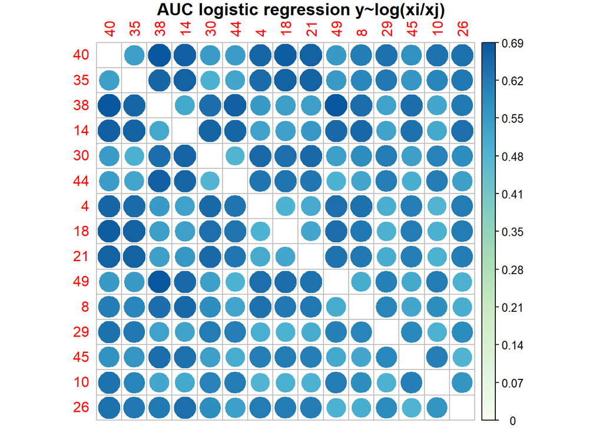

```r
#The output includes a plot of the association of the log-ratio with the outcome where the variables (taxa) are ranked by importance.
#Evidently, the most important variables are visually 40, 35, 38, 14, etc.
#The numerical ID of the most important taxa variables are obtained from the output of the function:
char_orderimportance<-diabetes_logratios$`order of importance`
class(char_orderimportance)
```

```
## [1] "integer"
```

```r
#[1] "integer"
char_orderimportance
```

```
##  [1] 40 35 38 14 30 44  4 18 21 49  8 29 45 10 26 28  6  2 48 19 17 47 20 27  3
## [26] 23 11 25  5 22 32 46 31 24 36 34 42 33  7 43 37  9 13 41 15 12 16 39  1
```

```r
#[1] 40 35 38 14 30 44  4 18 21 49  8 29 45 10 26 28  6  2 48 19 17 47 20 27  3 23 11 25  5 22 32 46 31 24
#[35] 36 34 42 33  7 43 37  9 13 41 15 12 16 39  1

#Vector of all genus NOT ordered by importance:
#taxanames[str_detect(taxanames$namestaxa,char_orderimportance), ]
#test<-taxanames[taxanames$namestaxa %like% char_orderimportance, ]
genus_vector<-taxanames[char_orderimportance %in% taxanames$taxanum, 3]
class(genus_vector)
```

```
## [1] "character"
```

```r
genus_vector
```

```
##  [1] "Dialister"              "Bacteroides"            "Akkermansia"
##  [4] "Faecalibacterium"       "Alistipes"              "Bacteroides"
##  [7] "Oscillibacter"          "Parabacteroides"        "Odoribacter"
## [10] "Prevotella"             "Holdemanella"           "Parasutterella"
## [13] "Collinsella"            "Roseburia"              "Butyricimonas"
## [16] "Phascolarctobacterium"  "Dorea"                  "Anaerostipes"
## [19] "Coprococcus"            "Methanobrevibacter"     "Agathobaculum"
## [22] "Streptococcus"          "Eubacterium"            "Escherichia"
## [25] "Fusicatenibacter"       "Flavonifractor"         "Bifidobacterium"
## [28] "Eubacterium"            "Eubacterium"            "Ruthenibacterium"
## [31] "Blautia"                "Blautia"                "Megamonas"
## [34] "Coprobacter"            "Lachnoclostridium"      "Veillonella"
## [37] "Ruminococcus"           "Haemophilus"            "Klebsiella"
## [40] "Erysipelatoclostridium" "Fusobacterium"          "Clostridium"
## [43] "Barnesiella"            "Megasphaera"            "Acidaminococcus"
## [46] "Paraprevotella"         "Lactobacillus"          "Lactobacillus"
## [49] "Lactobacillus"
```

```r
#The taxa numbers (not names) of the top 15 most important taxa variables are obtained from the output of the function:
names<-diabetes_logratios$`name of most important variables`
names
```

```
##  [1] "taxa40" "taxa35" "taxa38" "taxa14" "taxa30" "taxa44" "taxa4"  "taxa18"
##  [9] "taxa21" "taxa49" "taxa8"  "taxa29" "taxa45" "taxa10" "taxa26"
```

```r
class(names)
```

```
## [1] "character"
```

```r
#[1] "character"

#This lists corresponding top 15 genus but NOT by ordered importance:
df_top_taxa<-as.data.frame(taxanames[taxanames$namestaxa %in% names, 3])
df_top_taxa
```

```
##    taxanames[taxanames$namestaxa %in% names, 3]
## 1                              Faecalibacterium
## 2                               Parabacteroides
## 3                                    Prevotella
## 4                                     Roseburia
## 5                                  Anaerostipes
## 6                                 Agathobaculum
## 7                                Flavonifractor
## 8                                   Eubacterium
## 9                              Ruthenibacterium
## 10                            Lachnoclostridium
## 11                                  Haemophilus
## 12                       Erysipelatoclostridium
## 13                                  Megasphaera
## 14                              Acidaminococcus
## 15                                Lactobacillus
```

```r
#The output also reports the pair of taxa whose log-ratio is more associated with the outcome:
diabetes_logratios$`max log-ratio`
```

```
## [1] "40" "38"
```

```r
#The algorithm also provide the numerical values behind the correlation plot:
diabetes_logratios$`association log-ratio with y`[1:6,1:6]
```

```
##           40        35        38        14        30        44
## 40 0.0000000 0.5387382 0.6905212 0.6727065 0.5508077 0.5475465
## 35 0.5387382 0.0000000 0.6609570 0.6687900 0.4988418 0.5268516
## 38 0.6905212 0.6609570 0.0000000 0.5205273 0.6464340 0.6701920
## 14 0.6727065 0.6687900 0.5205273 0.0000000 0.6648278 0.6605303
## 30 0.5508077 0.4988418 0.6464340 0.6648278 0.0000000 0.4863456
## 44 0.5475465 0.5268516 0.6701920 0.6605303 0.4863456 0.0000000
```

```r
#We now illustrate the coda_glmnet algorithm with the qin.RData dataset
#FIRST USING DEAFAULT lambda.1se
#Calling function coda_glmnet() with the default lambda=“lambda.1se” specified as argument:
coda_glmnet_diabetes1<-coda_glmnet(x=x,y=metadata$disease,lambda="lambda.1se")
```

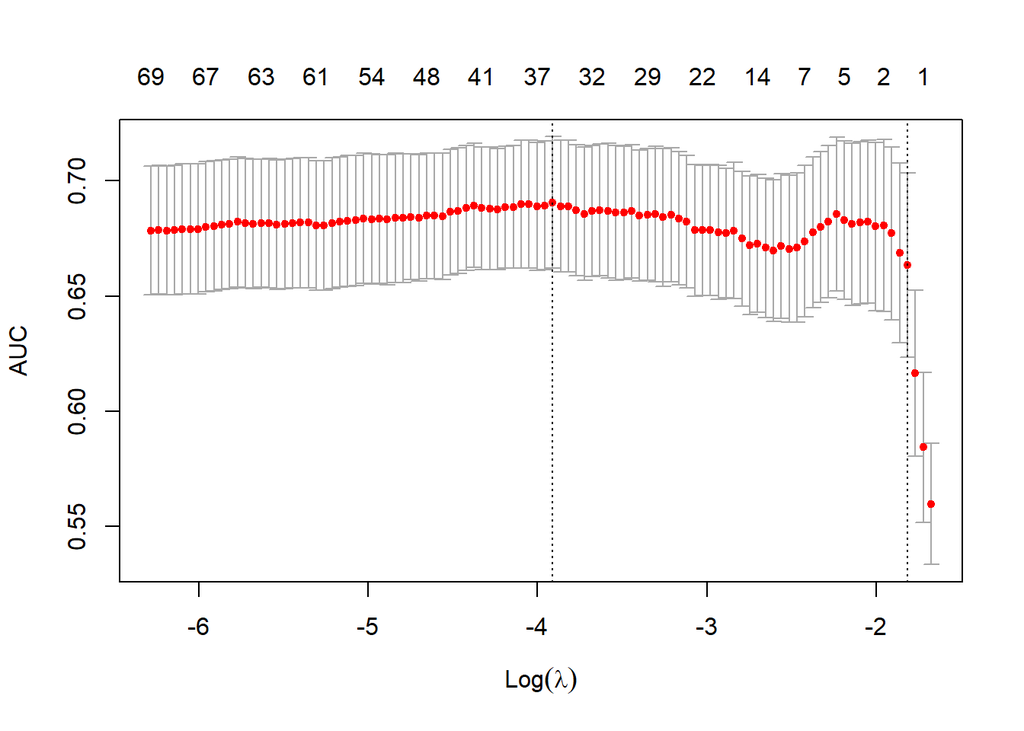

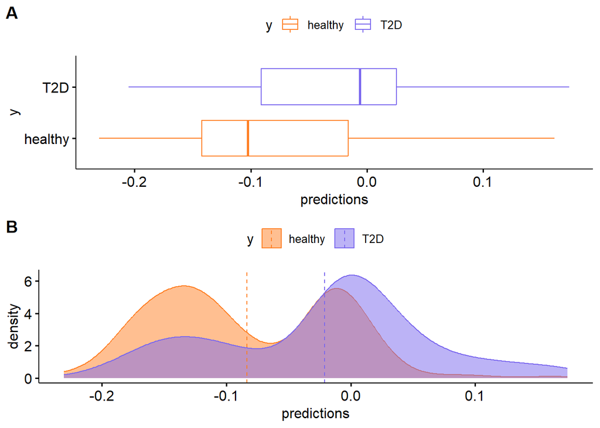

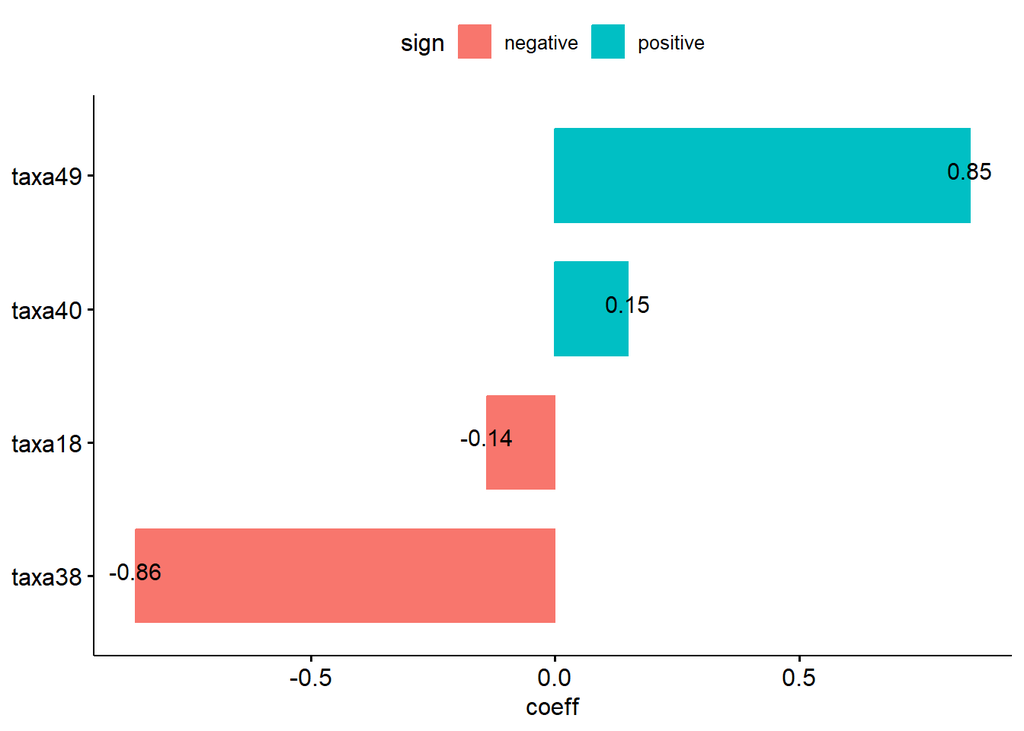

```r
#The algorithm identifies that the outcome is binary and implements a penalized logistic regression.
#The first plot shows the cross-validation accuracy (AUC) curve from cv.glmnet().
#Evidently, the default lambda (“lambda.1se”) selects  pairwise log-ratios that, as we see below,
#correspond to 4 different taxa. The model with lambda=lambda.min for variable reduction
#would otherwise select ~34 pairwise log-ratios.
##We see that with the default for lambda=“lambda.1se” the algorithm selects 1-2 pairwise
#log-ratios that correspond to 4 different taxa.

#The results of coda_glmnet include the taxaname of the selected taxa:
coda_glmnet_diabetes1$taxa.num
```

```
## [1] 18 38 40 49
```

```r
#The results of coda_glmnet include the number of selected taxa:
length(coda_glmnet_diabetes1$taxa.num)
```

```
## [1] 4
```

```r
#The results of coda_glmnet should include the genus of the selected taxaname but do NOT directly:
coda_glmnet_diabetes1$taxa.name
```

```
## [1] "taxa18" "taxa38" "taxa40" "taxa49"
```

```r
#[1] "taxa18" "taxa38" "taxa40" "taxa49"

#Getting the genus names corresponding to the obtained taxa:
df_genus_diabetes1<-as.data.frame(taxanames[taxanames$namestaxa %in% coda_glmnet_diabetes1$taxa.name, 3])
df_genus_diabetes1
```

```
##   taxanames[taxanames$namestaxa %in% coda_glmnet_diabetes1$taxa.name, 3]
## 1                                                           Anaerostipes
## 2                                                            Haemophilus
## 3                                                 Erysipelatoclostridium
## 4                                                          Lactobacillus
```

```r
# taxanames[taxanames$namestaxa %in% coda_glmnet_diabetes$taxa.name, 3]
# 1                                                          Anaerostipes
# 2                                                           Haemophilus
# 3                                                Erysipelatoclostridium
# 4                                                         Lactobacillus

#Based on these results,
# taxa18=Anaerostipes
# taxa38=Haemophilus
# taxa40=Erysipelatoclostridium
# taxa49=Lactobacillus

#The results of coda_glmnet should include the log-contrast coefficients:
coda_glmnet_diabetes1$`log-contrast coefficients`
```

```
## [1] -0.1390051 -0.8609949  0.1549202  0.8450798
```

```r
#[1] -0.1390051 -0.8609949  0.1549202  0.8450798

#By construction, the sum of the "parameterized" coefficients is equal to zero:
sum(coda_glmnet_diabetes1$`log-contrast coefficients`)
```

```
## [1] 8.326673e-17
```

```r
#[1] 8.326673e-17


#This constraint means that the model is a log-contrast function and this ensures the invariance principle for compositional data analysis.
#The microbiome signature is defined by the relative abundances of two groups of taxa, G1 (those taxa with positive coefficient) and G2 (those with negative coefficient).

#Taxa in G1 (ordered by importance):
coef_diabetes1<-coda_glmnet_diabetes1$`log-contrast coefficients`
positives_diabetes1<-which(coef_diabetes1>=0)
op_diabetes1<-order(coef_diabetes1[positives_diabetes1], decreasing = TRUE)
coda_glmnet_diabetes1$taxa.name[positives_diabetes1[op_diabetes1]]
```

```
## [1] "taxa49" "taxa40"
```

```r
#Taxa in G2 (ordered by importance):
negatives_diabetes1<-which(coef_diabetes1<0)
on_diabetes1<-order(abs(coef_diabetes1[coef_diabetes1<0]), decreasing = TRUE)
coda_glmnet_diabetes1$taxa.name[negatives_diabetes1[on_diabetes1]]
```

```
## [1] "taxa38" "taxa18"
```

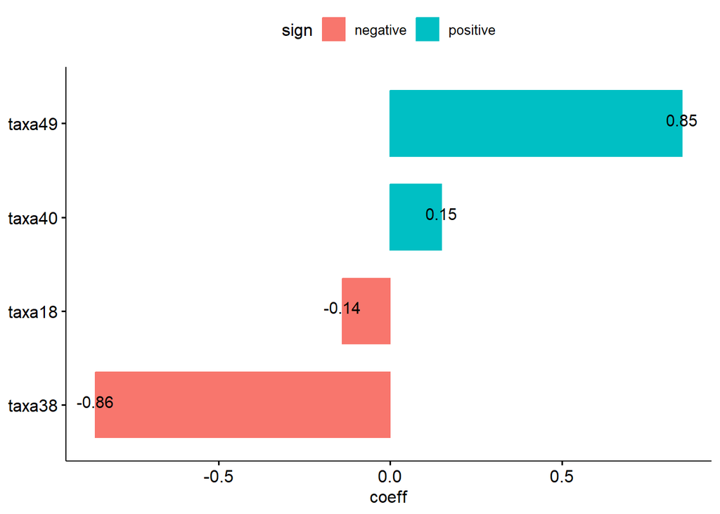

```r
#A graphical representation of the signature is again obtained with the signature plot that represents in a bar plot
#the selected taxa and their estimated regression coefficients.

coda_glmnet_diabetes1$`signature plot`
```

```r
#The output of the coda_glmnet() function also includes the predictions of the signature for each of the individuals
#in the sample:

head(coda_glmnet_diabetes1$`predictions`)
```

```
##                 [,1]
## CON.001 -0.006394488
## CON.002 -0.016168461
## CON.003 -0.135824564
## CON.004 -0.124416745
## CON.005 -0.007400435
## CON.006 -0.006833481
```

```r
#The algorithm provides three classification accuracy measures: the apparent AUC
#(the AUC of the signature applied to the same data that was used to generate the model) and
#the mean and sd of the cross-validation AUC (obtained from the output of cv.glmnet()):
# [,1]
# CON.001 -0.006394488
# CON.002 -0.016168461
# CON.003 -0.135824564
# CON.004 -0.124416745
# CON.005 -0.007400435
# CON.006 -0.006833481

coda_glmnet_diabetes1$`apparent AUC`
```

```
## [1] 0.7195672
```

```r
#[1] 0.7195672

coda_glmnet_diabetes1$`mean cv-AUC`
```

```
## [1] 0.6634771
```

```r
#[1] 0.6634771

coda_glmnet_diabetes1$`sd cv-AUC`
```

```
## [1] 0.03992182
```

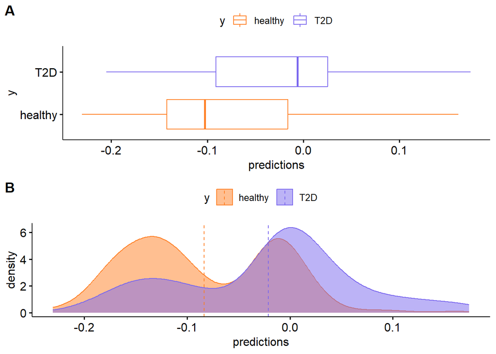

```r
#[1] 0.03992182

#The predictions plot that provide a graphical assessment of the classification accuracy of the
#microbiome signature are obtained:
coda_glmnet_diabetes1$`predictions plot`
```

```r
#With lambda.1se selected for variable reduction, based on these results
#the 2 taxa genus (taxa40=Erysipelatoclostridium and taxa49=Lactobacillus) with positive final coefficients
#are associated with T2D (type 2 Diabetes disease) IN RELATION TO the 2 taxa genus
#(taxa18=Anaerostipes and taxa38=Haemophilus) with negative coefficients that are associated with good health
#Preliminarily, it is concluded that default lambda=lambda.1se reduced approapriately the
#glm model to a minimal number of variables while maintaining AUC levels.default. The 4 taxa that
#were shown tobe significantly assocciated with T2D and good health were among the top15 identified
#in earlier log-ration exploration and thus appears satisfactory evidence that proper lambda value was chosen>

#The significance of the diabetes analysis is explored via performing a permutational test.
#This is specially advised for datasets with more variables than individuals, where over-fitting is very likely.
#Function coda_glmnet_null() implements this permutational test. It provides the distribution of mean cv-AUC under the null hypothesis by implementing the coda_glmnet() on different rearrangements of the response variable y.

#null_acc<-coda_glmnet_null(x=x,y=metadata$disease, niter=100)
#summary(null_acc$"accuracy")
# Min. 1st Qu.  Median    Mean 3rd Qu.    Max.
# 0.3790  0.4776  0.5032  0.5046  0.5294  0.6270

#null_acc$"confidence interval"
# 2.5%     97.5%
#   0.4043963 0.6039126
#Evidently, the mean cv-AUC is far from the region of expected values under the null.


#NOW COMPARATIVELY USING lambda.min FOR MODEL VARIABLE REDUCTION TO JUSTIFY USE OF DEFAULT lambda.1se:
#First, variables in environment will be removed to clear out cache and avoid potential overlapping calculations:
rm(list = ls())

setwd("C:/Users/click/OneDrive/Desktop/MY_R_DIRECTORY")
#Loading again necessary libraries
library(coda4microbiome)
library(glmnet)
library(phyloseq)
library("stringr")
library("data.table")
library(readr)
library(dplyr)
library(stringr)

set.seed(123)
load("C:/Users/click/OneDrive/Desktop/MY_R_DIRECTORY/qin.RData")
x<-impute_zeros(x)

taxanames$genus<-gsub(".*g__(.+)s__.*", "\\1", taxanames$taxanames)
taxanames$genus<-gsub("\\|", "", as.character(taxanames$genus))
taxanames$taxanum<-as.numeric(gsub("\\D", "", taxanames$namestaxa))
taxanames$taxanum2<-parse_number(taxanames$namestaxa)
metadata$disease<-factor(metadata$disease, levels=c("healthy","T2D"))

#Calling function coda_glmnet() with the default lambda=“lambda.min” specified as argument:
#Note: Not sure if environmental variables should be removed and if another seed(123) is needed.
coda_glmnet_diabetes2<-coda_glmnet(x=x,y=metadata$disease,lambda="lambda.min")
```

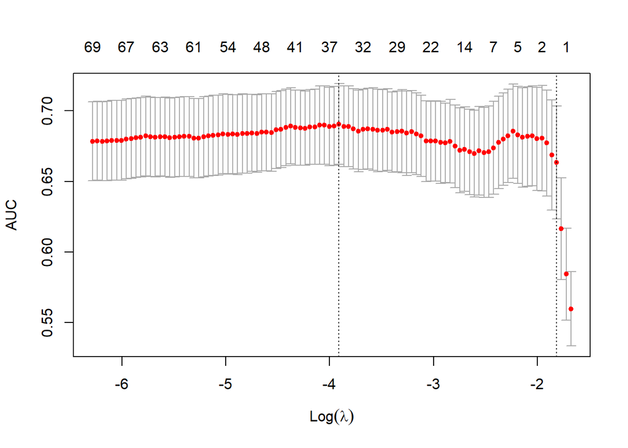

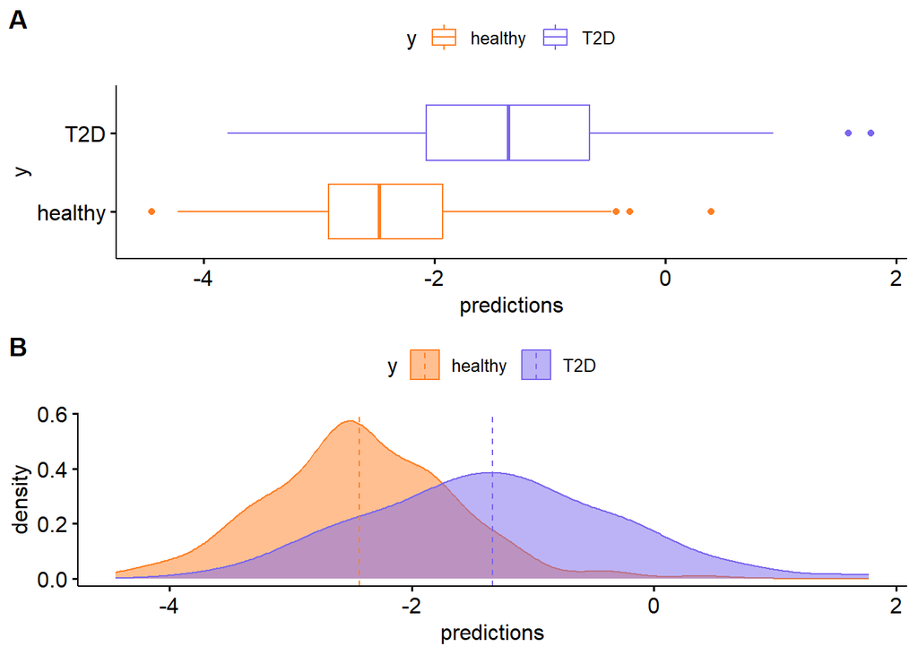

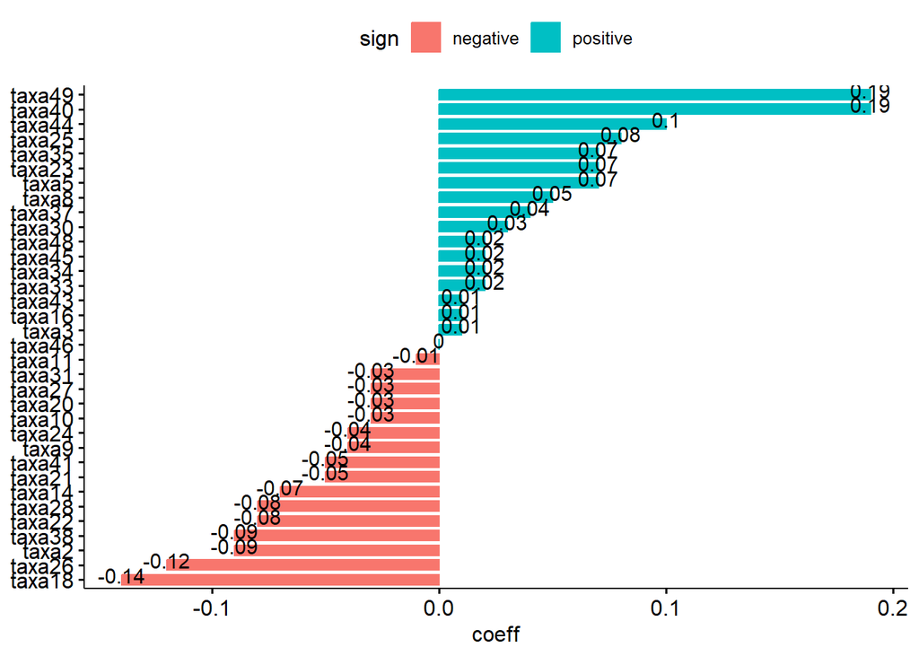

```r
#The algorithm identifies that the outcome is binary and implements a penalized logistic regression.
#The first plot shows the cross-validation accuracy (AUC) curve from cv.glmnet().
#Evidently, the lambda (“lambda.min”) selects 34 pairwise log-ratios that, as we see below,
#correspond to 34 different taxa.THis seems to be an excessive number of variables:
#We see that with the default for lambda=“lambda.min” the algorithm selects 34 pairwise log-ratios that correspond to 34 different taxa.

#The results of coda_glmnet include the taxaname of the selected taxa:
coda_glmnet_diabetes2$taxa.num
```

```
##  [1]  2  3  5  8  9 10 11 14 16 18 20 21 22 23 24 25 26 27 28 30 31 33 34 35 37
## [26] 38 40 41 43 44 45 46 48 49
```

```r
#The results of coda_glmnet include the number of selected taxa:
length(coda_glmnet_diabetes2$taxa.num)
```

```
## [1] 34
```

```r
#Evidently, more taxa were included by using non-default lambda=lambda.min (instead of 1 standard deviation)
#for variable reduction.

#The results of coda_glmnet should include the genus of the selected taxaname but do NOT directly:
coda_glmnet_diabetes2$taxa.name
```

```
##  [1] "taxa2"  "taxa3"  "taxa5"  "taxa8"  "taxa9"  "taxa10" "taxa11" "taxa14"
##  [9] "taxa16" "taxa18" "taxa20" "taxa21" "taxa22" "taxa23" "taxa24" "taxa25"
## [17] "taxa26" "taxa27" "taxa28" "taxa30" "taxa31" "taxa33" "taxa34" "taxa35"
## [25] "taxa37" "taxa38" "taxa40" "taxa41" "taxa43" "taxa44" "taxa45" "taxa46"
## [33] "taxa48" "taxa49"
```

```r
#Getting the genus names corresponding to the obtained taxa:
df_genus_diabetes2<-as.data.frame(taxanames[taxanames$namestaxa %in% coda_glmnet_diabetes2$taxa.name, 3])
df_genus_diabetes2
```

```
##    taxanames[taxanames$namestaxa %in% coda_glmnet_diabetes2$taxa.name, 3]
## 1                                                             Bacteroides
## 2                                                             Akkermansia
## 3                                                               Alistipes
## 4                                                         Parabacteroides
## 5                                                             Odoribacter
## 6                                                              Prevotella
## 7                                                            Holdemanella
## 8                                                               Roseburia
## 9                                                   Phascolarctobacterium
## 10                                                           Anaerostipes
## 11                                                     Methanobrevibacter
## 12                                                          Agathobaculum
## 13                                                          Streptococcus
## 14                                                            Eubacterium
```

[output cut: 20 more lines]

```r
#The results of coda_glmnet should include the log-contrast coefficients:
coda_glmnet_diabetes2$`log-contrast coefficients`
```

```
##  [1] -0.0892388968  0.0124090223  0.0691081284  0.0501132786 -0.0448269900
##  [6] -0.0319671373 -0.0084712509 -0.0688154480  0.0113288961 -0.1392122147
## [11] -0.0311813449 -0.0495689203 -0.0838475159  0.0729186025 -0.0374109416
## [16]  0.0774849896 -0.1163403268 -0.0326980234 -0.0827083668  0.0277967221
## [21] -0.0346503486  0.0205956224  0.0189007703  0.0701348264  0.0434598541
## [26] -0.0945857519  0.1934268859 -0.0544765221  0.0085516423  0.0984381362
## [31]  0.0184912808  0.0001393014  0.0203156922  0.1863863484
```

```r
#By construction, the sum of the "parameterized" coefficients is equal to zero:
sum(coda_glmnet_diabetes2$`log-contrast coefficients`)
```

```
## [1] -4.23923e-17
```

```r
#This constraint means that the model is a log-contrast function and this ensures the invariance principle for compositional data analysis.
#The microbiome signature is defined by the relative abundances of two groups of taxa, G1 (those taxa with positive coefficient) and G2 (those with negative coefficient).

#Taxa in G1 (ordered by importance):
coef_diabetes2<-coda_glmnet_diabetes2$`log-contrast coefficients`
positives_diabetes2<-which(coef_diabetes2>=0)
op_diabetes2<-order(coef_diabetes2[positives_diabetes2], decreasing = TRUE)
coda_glmnet_diabetes2$taxa.name[positives_diabetes2[op_diabetes2]]
```

```
##  [1] "taxa40" "taxa49" "taxa44" "taxa25" "taxa23" "taxa35" "taxa5"  "taxa8"
##  [9] "taxa37" "taxa30" "taxa33" "taxa48" "taxa34" "taxa45" "taxa3"  "taxa16"
## [17] "taxa43" "taxa46"
```

```r
#Taxa in G2 (ordered by importance):
negatives_diabetes2<-which(coef_diabetes2<0)
on_diabetes2<-order(abs(coef_diabetes2[coef_diabetes2<0]), decreasing = TRUE)
coda_glmnet_diabetes2$taxa.name[negatives_diabetes2[on_diabetes2]]
```

```
##  [1] "taxa18" "taxa26" "taxa38" "taxa2"  "taxa22" "taxa28" "taxa14" "taxa41"
##  [9] "taxa21" "taxa9"  "taxa24" "taxa31" "taxa27" "taxa10" "taxa20" "taxa11"
```

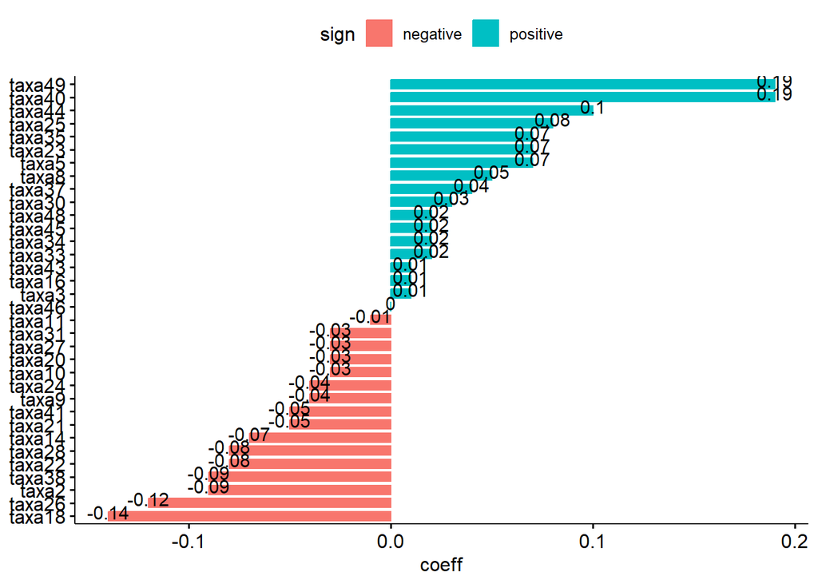

```r
#A graphical representation of the signature is again obtained with the signature plot that represents in a bar plot
#the selected taxa and their estimated regression coefficients.

coda_glmnet_diabetes2$`signature plot`
```

```r
#The output of the coda_glmnet() function also includes the predictions of the signature for each of the individuals
#in the sample:

head(coda_glmnet_diabetes2$`predictions`)
```

```
##              [,1]
## CON.001 -1.954377
## CON.002 -2.247463
## CON.003 -2.334175
## CON.004 -1.772297
## CON.005 -2.044404
## CON.006 -1.239125
```

```r
#The algorithm provides three classification accuracy measures: the apparent AUC
#(the AUC of the signature applied to the same data that was used to generate the model) and
#the mean and sd of the cross-validation AUC (obtained from the output of cv.glmnet()):


coda_glmnet_diabetes2$`apparent AUC`
```

```
## [1] 0.8057909
```

```r
coda_glmnet_diabetes2$`mean cv-AUC`
```

```
## [1] 0.6906061
```

```r
coda_glmnet_diabetes2$`sd cv-AUC`
```

```
## [1] 0.02858149
```

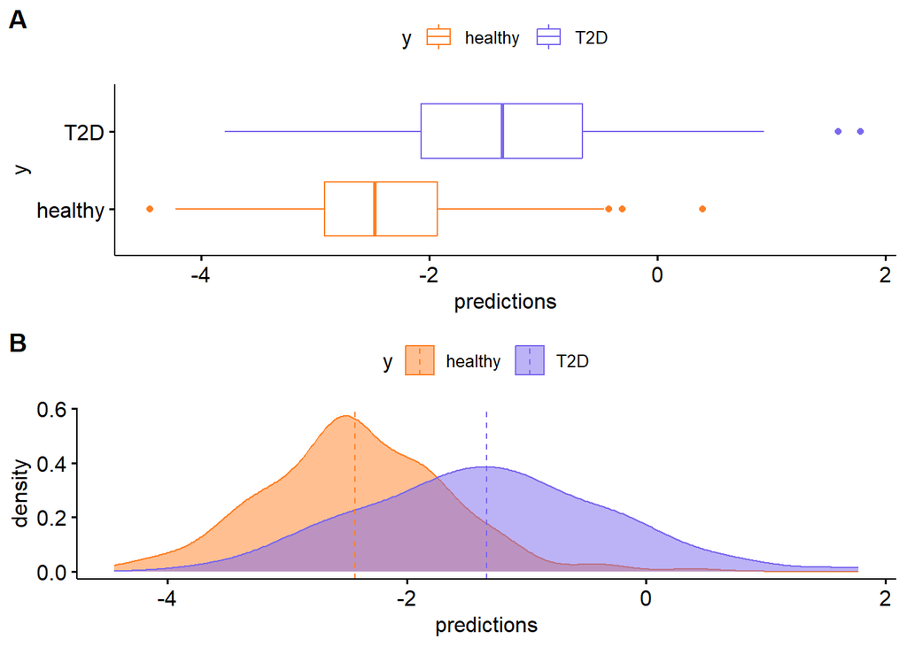

```r
#The predictions plot that provide a graphical assessment of the classification accuracy of the
#microbiome signature are obtained:
coda_glmnet_diabetes2$`predictions plot`
```

```r
#Based on the results when using lambda=lambda.min, the taxa corresponding to
#parameterized and final positive coefficients are associated with Type2Diabetes disease IN RELATION TO
#those with negative coefficients which are assocaited with good health.
#In conclusion, the glm model instead undergoes optimal variable reduction via
#default lambda=lambda.1se while maintaining AUC.
#The plots showed the cross-validation accuracy (AUC) curve from cv.glmnet().




# coda_glmnet_diabetes2$`apparent AUC`
# [1] 0.8057909
#   > coda_glmnet_diabetes2$`mean cv-AUC`
# [1] 0.6906061
#
#   > coda_glmnet_diabetes2$`sd cv-AUC`
# [1] 0.02858149




#PART#2
#The coda_glmnet_longitudinal() function is now used for the identification of microbial signatures in the
#longitudinal study
#A detailed description of the methodology can be found in Calle M.L. and Susin A. (2022)
#Identification of dynamic microbial signatures in longitudinal studies. BioRxiv.
#https://www.biorxiv.org/content/10.1101/2022.04.25.489415v1

#The algorithm checks if the outcome is binary or continuous and, for each pair of variables A
#and B, it provides the following measures of association between the outcome and the summary of the pairwise
#log-ratio trajectories, S(A/B):For binary outcomes:Discrimination accuracy (AUC) of the predictions of the logistic
#regression model glm(y~S(A/B)+covar) for the outcome Y
#Clearing variables and environment to prevent overlapping conflicts in calculations, etc.:

rm(list = ls())
#We will use the coda_glmnet_longitudinal algorithm with the Hansen.RData set:

setwd("C:/Users/click/OneDrive/Desktop/MY_R_DIRECTORY")
#Loading again necessary libraries
library(coda4microbiome)
library(glmnet)
library(phyloseq)
library("stringr")
library("data.table")
library(readr)
library(dplyr)
library(stringr)

set.seed(123)
load("C:/Users/click/OneDrive/Desktop/MY_R_DIRECTORY/Hansen.RData")

#Examining metagenomic phyloseq object components classes:
class(x)
```

```
## [1] "matrix" "array"
```

```r
class(metadata)
```

```
## [1] "data.frame"
```

```r
class(taxanames)
```

```
## [1] "character"
```

```r
#Examining metagenomic phyloseq object components dimensions:
dim(x)
```

```
## [1] 192 206
```

```r
dim(metadata)
```

```
## [1] 192  25
```

```r
dim(taxanames)
```

[output not shown]

```r
head(x)
```

[output not shown]

[output cut: 197 more lines]

[output not shown]

```r
x<-impute_zeros(x)

head(taxanames)
```

```
## [1] "k__Bacteria|p__Firmicutes|c__Clostridia|o__Clostridiales|f__Lachnospiraceae|g__Lachnospiraceae_unclassified|s__Eubacterium_rectale"
## [2] "k__Bacteria|p__Firmicutes|c__Clostridia|o__Clostridiales|f__Ruminococcaceae|g__Faecalibacterium|s__Faecalibacterium_prausnitzii"
## [3] "k__Bacteria|p__Firmicutes|c__Clostridia|o__Clostridiales|f__Eubacteriaceae|g__Eubacterium|s__Eubacterium_sp_CAG_180"
## [4] "k__Bacteria|p__Firmicutes|c__Clostridia|o__Clostridiales|f__Lachnospiraceae|g__Roseburia|s__Roseburia_inulinivorans"
## [5] "k__Bacteria|p__Bacteroidetes|c__Bacteroidia|o__Bacteroidales|f__Bacteroidaceae|g__Bacteroides|s__Bacteroides_vulgatus"
## [6] "k__Bacteria|p__Bacteroidetes|c__Bacteroidia|o__Bacteroidales|f__Bacteroidaceae|g__Bacteroides|s__Bacteroides_uniformis"
```

```r
head(metadata)
```

```
##               study_name subject_id body_site antibiotics_current_use
## SID5411-1 HansenLBS_2018    SID5411     stool                      no
## SID5411-2 HansenLBS_2018    SID5411     stool                      no
## SID5411-3 HansenLBS_2018    SID5411     stool                      no
## SID5411-4 HansenLBS_2018    SID5411     stool                      no
## SID5412-2 HansenLBS_2018    SID5412     stool                      no
## SID5412-1 HansenLBS_2018    SID5412     stool                      no
##           study_condition disease age age_category gender country
## SID5411-1         control healthy  59        adult   male     DNK
## SID5411-2         control healthy  59        adult   male     DNK
## SID5411-3         control healthy  59        adult   male     DNK
## SID5411-4         control healthy  59        adult   male     DNK
## SID5412-2         control healthy  50        adult   male     DNK
## SID5412-1         control healthy  50        adult   male     DNK
##           non_westernized sequencing_platform     PMID number_reads
## SID5411-1              no       IlluminaHiSeq 30425247     37138442
## SID5411-2              no       IlluminaHiSeq 30425247    104623436
## SID5411-3              no       IlluminaHiSeq 30425247     42646086
## SID5411-4              no       IlluminaHiSeq 30425247     86629592
## SID5412-2              no       IlluminaHiSeq 30425247     63272720
## SID5412-1              no       IlluminaHiSeq 30425247     41744932
##           number_bases minimum_read_length median_read_length NCBI_accession
## SID5411-1   3713844200                 100                100     SRR7989829
## SID5411-2  10462343600                 100                100     SRR7989830
## SID5411-3   4264608600                 100                100     SRR7989965
## SID5411-4   8662959200                 100                100     SRR7989967
## SID5412-2   6327272000                 100                100     SRR7989915
## SID5412-1   4174493200                 100                100     SRR7989941
##                  curator      BMI days_from_first_collection   location
## SID5411-1 Giacomo_DAmato 30.56748                          0 Copenhagen
## SID5411-2 Giacomo_DAmato 30.45701                         56 Copenhagen
## SID5411-3 Giacomo_DAmato 30.93044                        107 Copenhagen
## SID5411-4 Giacomo_DAmato 30.85153                        162 Copenhagen
## SID5412-2 Giacomo_DAmato 30.07378                         60 Copenhagen
## SID5412-1 Giacomo_DAmato 30.60912                          0 Copenhagen
##           uncurated_metadata           Diet ID_num
## SID5411-1    low_gluten_diet low_to_high_GD      1
## SID5411-2    low_gluten_diet low_to_high_GD      1
## SID5411-3   high_gluten_diet low_to_high_GD      1
## SID5411-4   high_gluten_diet low_to_high_GD      1
## SID5412-2   high_gluten_diet high_to_low_GD      2
## SID5412-1   high_gluten_diet high_to_low_GD      2
```

```r
metadata$Diet<-factor(metadata$Diet, levels=c("low_to_high_GD","high_to_low_GD"))

#Assigning variables for longitudinal study to track trajectories of log-ratios over time:

#Microbiome abundance
x=x
# observation times
x_time = metadata$days_from_first_collection;
# subject id
subject_id = metadata$subject_id;
# diet categorical binary response variable (low-to-high, high-to-low )
y= metadata$Diet;
# observation times
ini_time = 0;
end_time = 180;

#We first call function explore_lr_longitudinal() with the default parameters to explore log ratios:
ecam_logratios<-explore_lr_longitudinal(x,y, x_time, subject_id, ini_time, end_time)
```

[output not shown]

[output cut: 191 more lines]

[output not shown]

[output cut: 16 more lines]

[output not shown]

[figure not shown]

```r
#The correlation-like plot provides the association between the outcome (diet) and the summary of each pairwise
#log-ratios trajectories. The variables composing the log-ratio are indicated and are ranked according to their
#aggregated association with the outcome:
#According to the plot and the output of the functions, the most important taxa related to diet are:
ecam_logratios$`order of importance`
```

```
##   [1] 151  79  14  45  67 113 136  25  95  20   4  74  32 127  98  38  11  88
##  [19]  64 110  75 141 144  28 164 138  48  57  63  43  86  27   5  23  55  89
##  [37] 109  81  17 112 152  13  65 129 139  53 117  56  71  50  61  37 119 162
##  [55]  18 193 199 126 181 115 179 143 133  73 173 180 191  60 128 156 196 182
##  [73] 111 204  99  97 105 124 186 195 132 150 205 184 101  49 206 172  35 194
##  [91]  41  93 114 146 192 166 149  66 185 165 177 203  84 153 116 198 189  34
## [109] 183 154 171 140 135 200 130  30 170 175  91   9 137   2 187  46  52 103
## [127]  47 202  87 142 168 167   7 174 163 201 188  36  33 161  24 157 160  39
## [145]  10  90  51  82 102 123 178 155  68  31 197 190 159  62  54 134 169  77
## [163]  29  78  19  72 158 147  15 106   8 108  59  92  12 100 145 125  40  44
## [181] 131  69 121  22 107  16  70  58  80 118  96 120  21  94   1  83 176 148
## [199]  85   6  42  76 122 104  26   3
```

```r
# [1] 151  79  14  45  67 113 136  25  95  20   4  74  32 127  98  38  11  88  64 110  75 141 144  28 164 138  48  57  63  43  86  27
# [33]   5  23  55  89 109  81  17 112 152  13  65 129 139  53 117  56  71  50  61  37 119 162  18 193 199 126 181 115 179 143 133  73
# [65] 173 180 191  60 128 156 196 182 111 204  99  97 105 124 186 195 132 150 205 184 101  49 206 172  35 194  41  93 114 146 192 166
# [97] 149  66 185 165 177 203  84 153 116 198 189  34 183 154 171 140 135 200 130  30 170 175  91   9 137   2 187  46  52 103  47 202
# [129]  87 142 168 167   7 174 163 201 188  36  33 161  24 157 160  39  10  90  51  82 102 123 178 155  68  31 197 190 159  62  54 134
# [161] 169  77  29  78  19  72 158 147  15 106   8 108  59  92  12 100 145 125  40  44 131  69 121  22 107  16  70  58  80 118  96 120
# [193]  21  94   1  83 176 148  85   6  42  76 122 104  26   3

ecam_logratios$`name of most important variables`
```

```
##  [1] "taxa151" "taxa79"  "taxa14"  "taxa45"  "taxa67"  "taxa113" "taxa136"
##  [8] "taxa25"  "taxa95"  "taxa20"  "taxa4"   "taxa74"  "taxa32"  "taxa127"
## [15] "taxa98"
```

```r
#The pair of taxa whose log-ratio is more associated with the diet are:

ecam_logratios$`max log-ratio`
```

```
## [1] "151" "136"
```

```r
taxanames[as.numeric(ecam_logratios$`max log-ratio`)]
```

```
## [1] "k__Bacteria|p__Firmicutes|c__Negativicutes|o__Acidaminococcales|f__Acidaminococcaceae|g__Phascolarctobacterium|s__Phascolarctobacterium_faecium"
## [2] "k__Bacteria|p__Firmicutes|c__Erysipelotrichia|o__Erysipelotrichales|f__Erysipelotrichaceae|g__Erysipelatoclostridium|s__Clostridium_spiroforme"
```

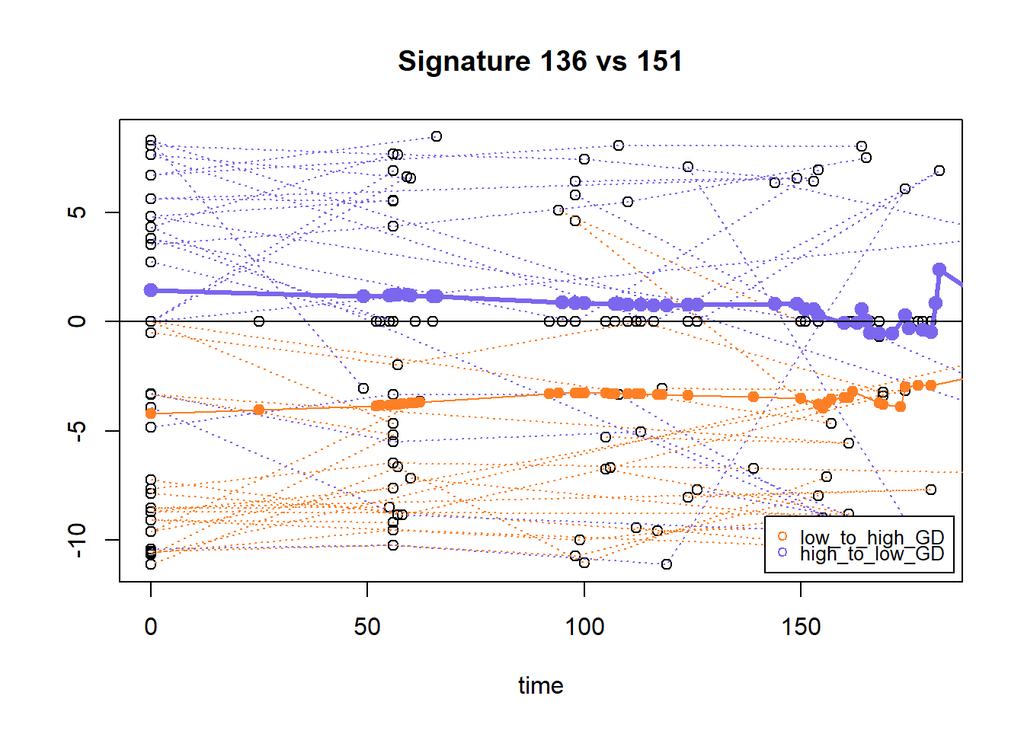

```r
# g__Phascolarctobacterium
# g__Erysipelatoclostridium

#We use function plot_signature_curves() to see the log-ratio trajectories for the pair of variables with maximum discrimination.

plot_signature_curves(c(136,151), c(1,-1),x,y, x_time, subject_id, ini_time, end_time)
```

[output not shown]

[output cut: 192 more lines]

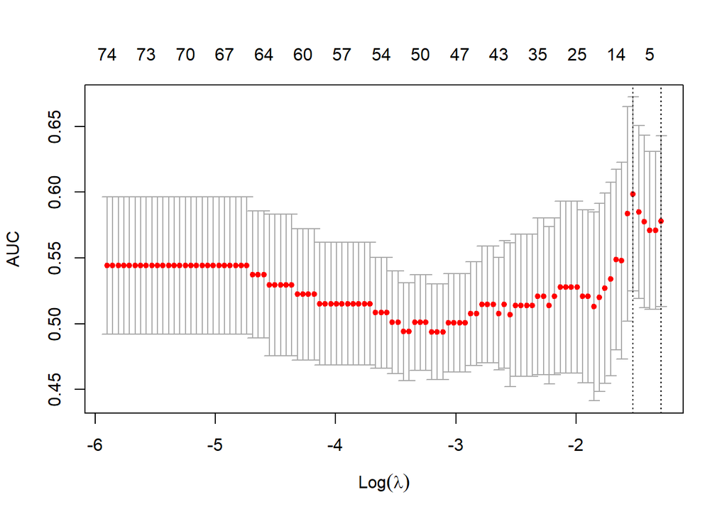

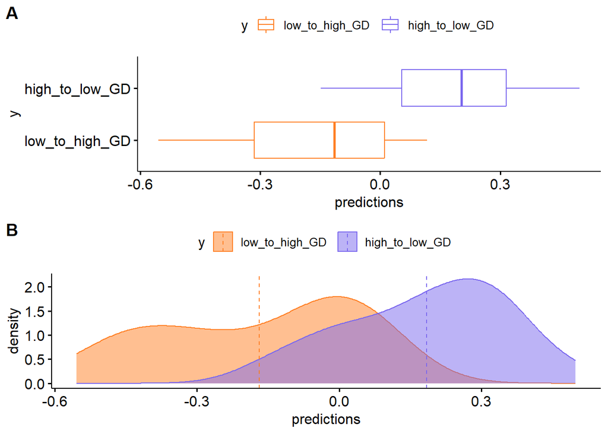

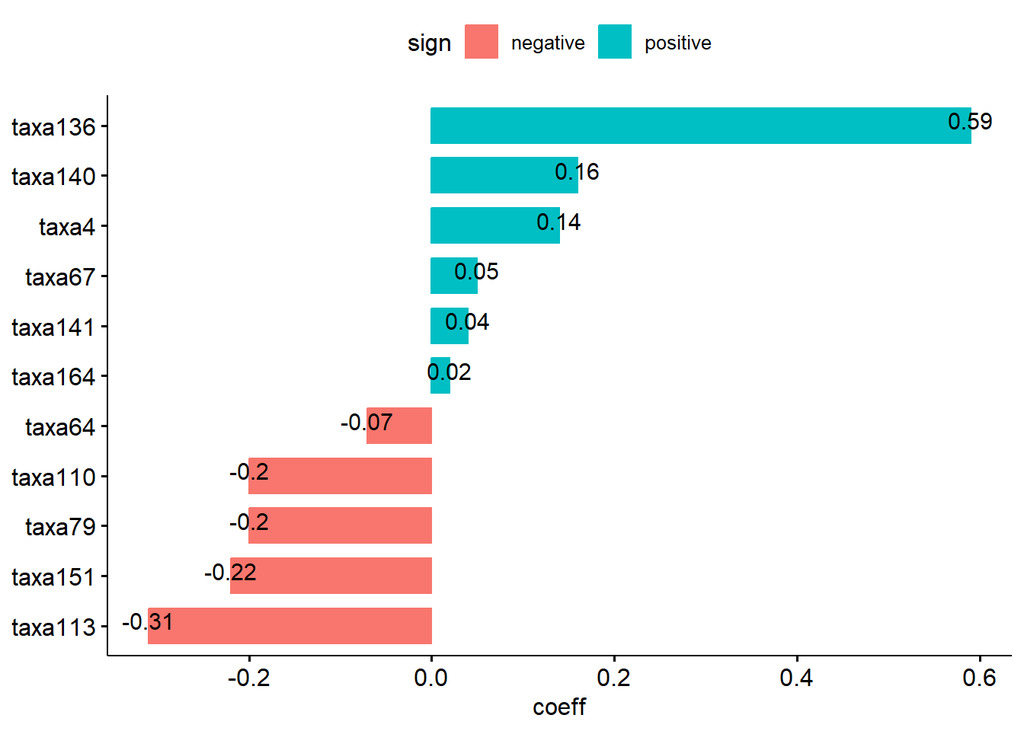

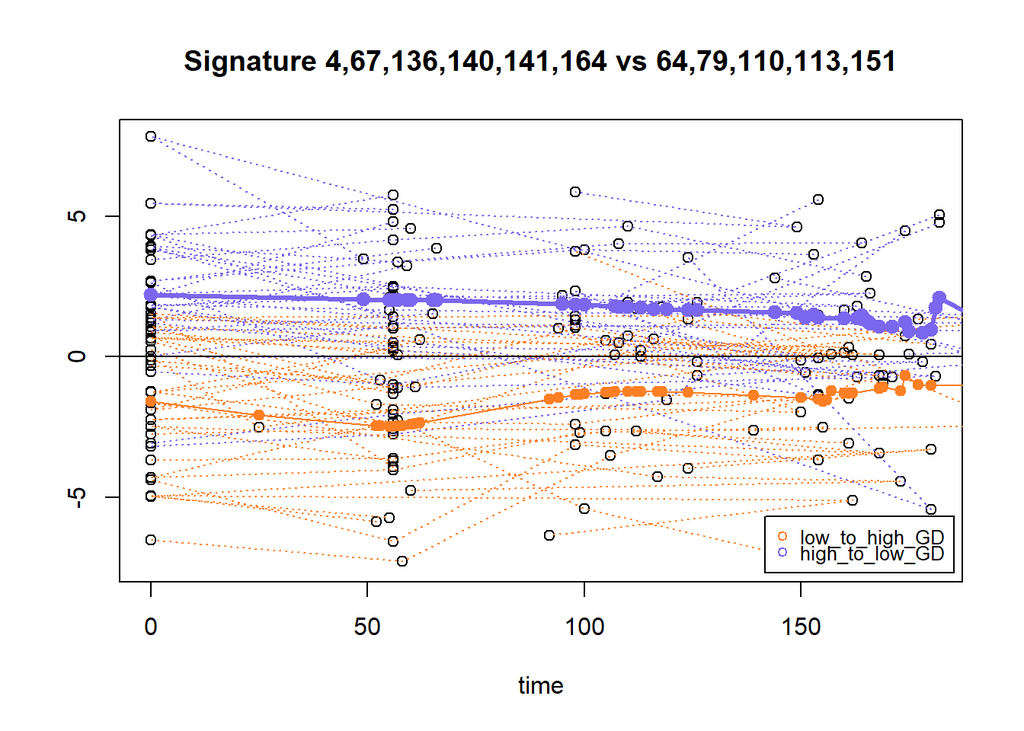

```r
#We now implement the analysis with function coda_glmnet_longitudinal() with the default parameters except for lambda and nfolds.
#Based on metadata dataframe examination, because of the small sample size in “1-4” groups we specified nfolds=4 for the cross-validation penalized regression
#and set lambda="lambda.min" after observing the cross-validation accuracy (AUC) curve:

ecam1 <-coda_glmnet_longitudinal (x,y, x_time, subject_id, ini_time, end_time, lambda="lambda.min",nfolds=4)
```